# Chapter 3 Supplement

```r
library(tidyverse)
library(zoo)
library(deSolve)
library(ggforce)
```

## Initial values estimation

### Value of $N$:

```r
N <- mean(new_york_population$pop)
N
```

```
## [1] 7842545
```

### Initial value for $R$:

```r
R_0 <- 6/7*N
R_0
```

```
## [1] 6722182
```

### Initial value for $I$:

Approximate estimate number of infections vs observed number of infections:

```r
10/70*N
```

```
## [1] 1120364
```

```r
sum(new_york_measles$cases)
```

```
## [1] 187328.2
```

Reporting efficiency:

```r
rho <- sum(new_york_measles$cases)/(1/2*20/70*N)
rho
```

```
## [1] 0.1672031
```

Rolling average cases data frame:

```r
new_york_roll_avg <- new_york_measles %>%
  mutate(cases = rollmean(cases,k=52,fill=NA,align = "left")) %>%
  select(numdate,cases) %>%
  mutate(Series = "rolling_avg")
```

Initial rolling average cases, then adjusted for under-reporting:

```r
new_york_roll_avg$cases[1]
```

```
## [1] 422.3226
```

```r
I_0 <- new_york_roll_avg$cases[1]/rho
I_0
```

```
## [1] 2525.806
```

### Initial value for $E$:

Second week of rolling average cases, then adjusted for under-reporting:

```r
new_york_roll_avg$cases[2]
```

```
## [1] 419.5494
```

```r
E_0 <- new_york_roll_avg$cases[2]/rho
E_0
```

```
## [1] 2509.221
```

### Initial value for $S$:

```r
S_0 <- N - E_0 - I_0 - R_0
S_0
```

```
## [1] 1115329
```

### Population parameter estimation

Maximum change yearly change in population size from 1950-1960:

```r
max(abs(new_york_population$dpop/new_york_population$pop))
```

```
## [1] 0.005567506
```

Mean birth rate per capita is given by:

```r
mu <- mean(new_york_population$births/new_york_population$pop)
mu
```

```
## [1] 0.02096239
```

Mean death rate per capita is given by:

```r
mean(new_york_population$deaths/new_york_population$pop)
```

```
## [1] 0.01047417
```

# Epidemiological Parameter estimation

### Estimating $\sigma$

```r
sigma <- 365/8.58
sigma
```

```
## [1] 42.54079
```

### Estimating $\gamma$

```r
12.5-8.58 + 1
```

```
## [1] 4.92
```

```r
gamma <- 365/(12.5-8.58 + 1)
gamma
```

```
## [1] 74.18699
```

### Calibrating $\beta$

Ball-park estimate for $\beta$:

```r
beta <- 1e-04
```

Differential equations:

```r
SEIR_ode <- function(t,y,params){
  S <- y[1]
  E <- y[2]
  I <- y[3]
  R <- y[4]
  N <- y[5]

  mu <- params[1]
  beta <- params[2]
  sigma <- params[3]
  gamma <- params[4]

  return(list(c(mu*N - mu*S - beta*S*I, #dS/dt
                beta*S*I - (mu + sigma)*E, #dE/dt
                sigma*E - (mu + gamma)*I, #dI/dt
                gamma*I - mu*R, #dR/dt
                0))) #dN/dt
}
```

Entering initial conditions, parameters and output times

```r
y_0 <- c(S_0,E_0,I_0,R_0,N) #initial conditions
params <- c(mu,beta,sigma,gamma) #parameters

times <- seq(0,10,1/52) #outputs will be produced each week for a 10 year period.
```

Solution for $\beta = 10^{-4}$:

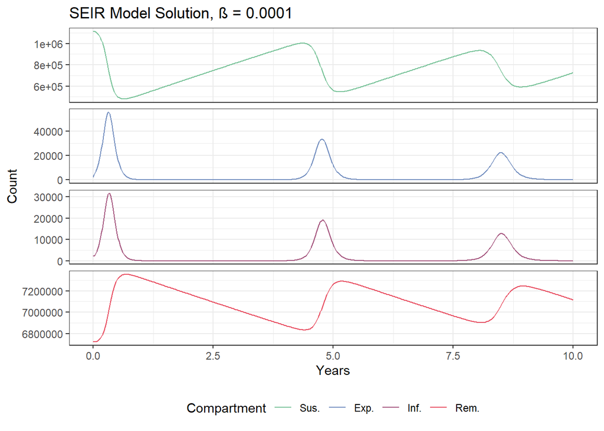

```r
SEIR_soln <- ode(y = y_0,times = times,func = SEIR_ode,parms = params) #numerical solution of equations


SEIR_soln_df <- as.data.frame(SEIR_soln)
names(SEIR_soln_df) <- c("time","Sus.","Exp.","Inf.","Rem.","N")

SEIR_soln_df %>%
  pivot_longer(cols = 2:6,names_to = "Compartment",values_to = "Cases") %>%
  mutate(Compartment = fct_relevel(Compartment,c("Sus.","Exp.","Inf.","Rem."))) %>%
  filter(Compartment != "N") %>%
  #mutate(Cases = rollmean(Cases,k=52,fill=NA)) %>%
  ggplot(aes(x=time,y=Cases,group = Compartment,color=Compartment)) +
  geom_line() +
  facet_grid(Compartment ~.,scales="free") +
  labs(title = "SEIR Model Solution, β = 0.0001",x = "Years",y = "Count") +
  theme(strip.text.y = element_blank()) +
  theme_bw()+
  scale_color_manual(values = c("#77c298","#718dbf","#a4547d","#e84d60")) +
  theme(legend.position = "bottom",strip.text.y = element_blank())
```

Function for finding differential equation solutions for different values of $\beta$

```r
beta_test <- function(beta,y_0,params){ #function finds SEIR solutions

  param_test <- params

  param_test[2] <- beta

  times <- seq(0,10,by=1/52)

  SEIR_soln <- ode(y = y_0,times = times,func = SEIR_ode,parms = param_test)

  SEIR_soln_df <- as.data.frame(SEIR_soln)

  names(SEIR_soln_df) <- c("time","Sus.","Exp.","Inf.","Rem.","N")

  return(SEIR_soln_df)
}

find_period <- function(beta_df){ #estimates the inter-epidemic period from solution
  beta_diff <- diff(beta_df$Sus.) %>%
    rollapply(2,function(x){x[1]*x[2]>0}) #numerical derivatives of the SEIR solution
  times <- beta_df[[1]][2:(dim(beta_df)[1]-1)]
  critical <- as.data.frame(cbind(times,beta_diff)) %>%
    filter(beta_diff == 0) #finds critical points in solution
  critical <- critical[1:floor(dim(critical)[1]/2)*2,]
  return(mean(diff(critical$times)))
  # returns mean period between maxima
}
```

[output not shown]

# Initial Comparison with original data

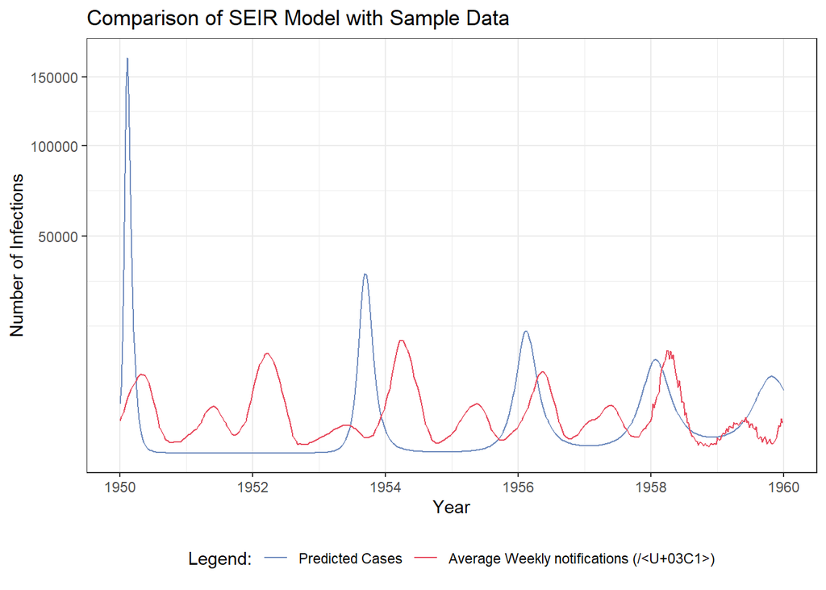

```r
cal_beta <- beta_test(0.0002715625,y_0,params) %>%
  # mutate(cases = rollmean(Inf.,k=52,fill=NA)) %>%
  # mutate(time = time + 1948.5)
  mutate(cases = Inf.,time = time + 1950)

# cal_beta

ggplot() +
  geom_line(data = cal_beta,aes(x=time,y=cases,color="1")) +
  geom_line(data = new_york_measles,aes(x=numdate,y=cases/rho,color="2")) +
  labs(title = "Comparison of SEIR Model with Sample Data",x= "Year",y="Number of Infections") +
  scale_x_continuous(breaks = seq(1950,1960,2)) +
  scale_y_sqrt() +
  theme(legend.position = "bottom") +
  scale_color_manual(values = c("#718dbf","#e84d60"),name="Legend:",labels = c("Predicted Cases","Average Weekly notifications (/ρ)")) +
  theme_bw() +
  theme(legend.position = "bottom")
```

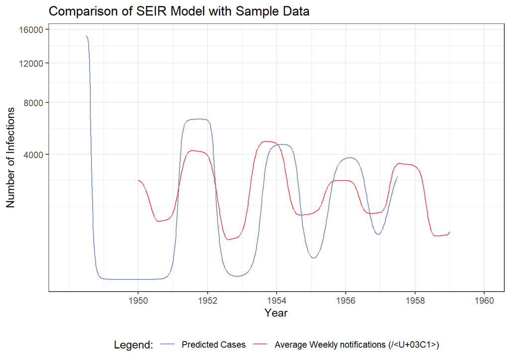

```r
cal_beta <- beta_test(0.0002715625,y_0,params) %>%
  mutate(cases = rollmean(Inf.,k=52,fill=NA)) %>%
  mutate(time = time + 1948)

# cal_beta

ggplot() +
  geom_line(data = cal_beta,aes(x=time,y=cases,color="1")) +
  geom_line(data = new_york_roll_avg,aes(x=numdate,y=cases/rho,color="2")) +
  labs(title = "Comparison of SEIR Model with Sample Data",x= "Year",y="Number of Infections") +
  scale_x_continuous(breaks = seq(1950,1960,2)) +
  scale_y_sqrt() +
  theme(legend.position = "bottom") +
  scale_color_manual(values = c("#718dbf","#e84d60"),name="Legend:",labels = c("Predicted Cases","Average Weekly notifications (/ρ)")) +
  theme_bw() +
  theme(legend.position = "bottom")
```

## Estimating $\beta$ and $\delta \beta$

Creating a data frame with values to run the algorithm:

```r
S_est <- new_york_measles %>%
  #taking a rolling mean to smooth the data for ease
  mutate(cases = rollmean(cases,k=4,fill=NA)) %>%
  filter(!is.na(cases)) %>% #filtering out NA values
  mutate(year = floor(numdate)) %>%
  merge(new_york_population,by = "year") %>% #merging case data with population data
  #converting births/deaths per year to births/deaths per week
  mutate(births_per_week = births/52,deaths_per_week = deaths/52)
head(S_est)
```

|  | year | yyyy.mm.dd | numdate | cases | pop | births | deaths | infmort | vaccprop | dpop | births_per_week | deaths_per_week |
| --- | --- | --- | --- | --- | --- | --- | --- | --- | --- | --- | --- | --- |
| 1 | 1950 | 07/01/1950 | 1950.019 | 244.1068 | 7903000 | 155818 | 79082 | 3858 | NA | 44000 | 2996.5 | 1520.808 |
| 2 | 1950 | 14/01/1950 | 1950.038 | 290.6568 | 7903000 | 155818 | 79082 | 3858 | NA | 44000 | 2996.5 | 1520.808 |
| 3 | 1950 | 21/01/1950 | 1950.057 | 346.7159 | 7903000 | 155818 | 79082 | 3858 | NA | 44000 | 2996.5 | 1520.808 |
| 4 | 1950 | 28/01/1950 | 1950.077 | 413.2636 | 7903000 | 155818 | 79082 | 3858 | NA | 44000 | 2996.5 | 1520.808 |
| 5 | 1950 | 04/02/1950 | 1950.096 | 486.5011 | 7903000 | 155818 | 79082 | 3858 | NA | 44000 | 2996.5 | 1520.808 |
| 6 | 1950 | 11/02/1950 | 1950.115 | 556.1989 | 7903000 | 155818 | 79082 | 3858 | NA | 44000 | 2996.5 | 1520.808 |

Reconstructing $S$:

```r
S_est$S_reconstruct <- rep(S_0,dim(S_est)[1]) #creating a column for reconstructed S values, starting with S_0

for(i in 1:(dim(S_est)[1]-4)){
  S_est$S_reconstruct[i+1] <- S_est$S_reconstruct[i] + S_est$births_per_week[i] - S_est$deaths_per_week[i]/N*S_est$S_reconstruct[i]- 1/rho*S_est$cases[i+3]
} #implementing algorithm for reconstructing S
```

Estimating $\beta_t$ from $S$ reconstruction:

```r
S_est$beta_est <-  rep(NA,dim(S_est)[1]) #initialising column of estimates for beta

gamma <- 7/4.92 #setting gamma as a rate in weeks

for(i in 4:dim(S_est)[1]){
  S_est$beta_est[i] <- 1/S_est$S_reconstruct[i]*S_est$cases[i-1]/S_est$cases[i-3]*(gamma + S_est$deaths_per_week[i]/N)
}
```

Graph of reconstructed values:

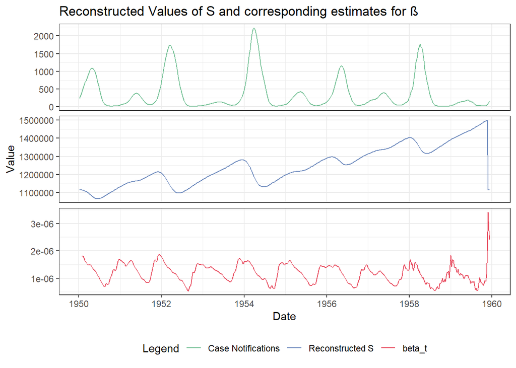

```r
S_est %>%
  select(numdate,cases,S_reconstruct,beta_est) %>%
  pivot_longer(cols = c("cases","S_reconstruct","beta_est")) %>%
  mutate(name = fct_relevel(name,c("cases","S_reconstruct","beta_est"))) %>%
  ggplot() +
  geom_line(aes(x = numdate,y=value,color=name)) +
  facet_grid(name ~ .,scales = "free") +
  labs(title = "Reconstructed Values of S and corresponding estimates for β",x = "Date",y = "Value") +
  scale_color_manual(values = c("#77c298","#718dbf","#e84d60"),labels = c("Case Notifications","Reconstructed S", "beta_t"),name = "Legend") +
  theme_bw() +
  scale_x_continuous(breaks = seq(1950,1960,2)) +
  theme(legend.position = "bottom") +
  theme(strip.text.y = element_blank())
```

Estimating $\beta_0$:

Monthly median values for $\beta$

```r
median_beta <- S_est %>%
  mutate(month = floor((numdate-year)*12)+1) %>% #adding a month column
  filter(!is.na(beta_est)) %>%
  group_by(month) %>%
  summarise(median_beta = median(beta_est))

median_beta
```

| month | median_beta |
| --- | --- |
| 1 | 1.571124e-06 |
| 2 | 1.447017e-06 |
| 3 | 1.416003e-06 |
| 4 | 1.271604e-06 |
| 5 | 1.152949e-06 |
| 6 | 9.965302e-07 |
| 7 | 8.394060e-07 |
| 8 | 7.051893e-07 |
| 9 | 7.966548e-07 |
| 10 | 1.082538e-06 |

[output cut: 2 more lines]

Mean of monthly median values for $\beta$

```r
beta_0 <- mean(median_beta$median_beta)

beta_0
```

```
## [1] 1.185033e-06
```

Converting this to a rate in years:

```r
beta_0 <- beta_0*52
beta_0
```

```
## [1] 6.162174e-05
```

Estimating $\delta \beta$:

Range of values of the medians:

```r
range(median_beta$median_beta)
```

```
## [1] 7.051893e-07 1.571124e-06
```

Estimate:

```r
delta_beta <- (c(-1,1)%*%range(median_beta$median_beta)/2/mean(median_beta$median_beta))[1]
delta_beta
```

```
## [1] 0.3653631
```

Setting the $\phi$ value:

```r
phi <- pi/6
```

Boxplot of reconstructed $\beta$ values for each month:

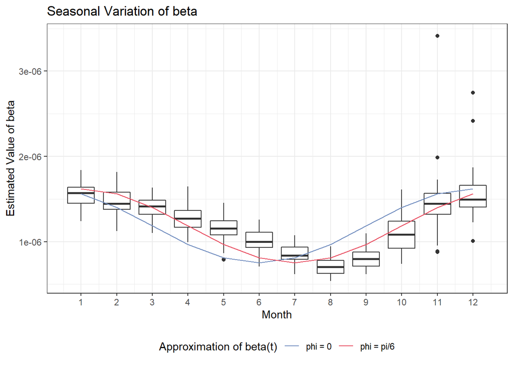

```r
S_est %>%
  mutate(month = floor((numdate-year)*12)+1) %>%
  ggplot() +
  geom_boxplot(aes(x = month,y=beta_est,group=month)) +
  geom_line(aes(x = month,y = beta_0/52*(1 + delta_beta*cos(2*pi*((month)/12))),color="phi = 0")) +
  geom_line(aes(x = month,y = beta_0/52*(1 + delta_beta*cos(2*pi*((month-1)/12-1))),color="phi = pi/6")) +
  scale_x_continuous(breaks = 1:12) +
  theme_bw() +
  labs(title = "Seasonal Variation of beta",y = "Estimated Value of beta",x = "Month") +
  scale_color_manual(values = c("#718dbf","#e84d60"),name = "Approximation of beta(t)") +
  theme(legend.position = "bottom")
```

Resetting gamma to rate per year:

```r
gamma <- 365/4.56
```

Adapted set of SEIR equations with seasonal effect:

```r
beta_t <- function(beta_0,delta_beta,phi,t){
  return(beta_0*(1 + delta_beta*cos(2*pi*t+phi)))
} #model for seasonal variation

SEIR_ode <- function(t,y,params){
  S <- y[1]
  E <- y[2]
  I <- y[3]
  R <- y[4]
  N <- y[5]

  mu <- params[1]
  beta_0 <- params[2]
  delta_beta <- params[3]
  phi <- params[4]
  sigma <- params[5]
  gamma <- params[6]

  return(list(c(mu*N - mu*S - beta_t(beta_0,delta_beta,phi,t)*S*I, #dS/dt
                beta_t(beta_0,delta_beta,phi,t)*S*I - (mu + sigma)*E, #dE/dt
                sigma*E - (mu + gamma)*I, #dI/dt
                gamma*I - mu*R, #dR/dt
                0))) #dN/dt
}
```